# Introdução ao Software Estatístico R

Prof. Dr. THIAGO S MOTA - FATEC Botucatu

08/11/2019

## Introdução

O uso de softwares e pacotes estatísticos para a análise de dados é de grande importância, desde o desenvolvimento e aplicação. Contudo, observar-se que os softwares e pacotes apresentam um custo elevado. Com isso surgiu à necessidade da criação de softwares livres.

O software R, além de ser gratuito, tem código-fonte aberto, podendo ser modificado ou implementado com novos procedimentos e funções desenvolvidas pelos seus usuários. O Software R é, portanto, uma importante ferramenta para a análise e manipulação de dados, por apresentar um vasto número de ferramentas, tais como: testes não paramétricos, testes paramétricos, modelagem linear e não linear, análise de séries temporais, análise de sobrevivência, redes neurais, modelos de machine learning, entre outras ferramentas.

## Instalando o R

Para instalar o R, basta conectar-se ao site [Baixando o R](http://www.r-project.org/), escolher um local mais próximo que você se encontra. No caso do Brasil, existem quatro opções: Universidade federal do Paraná (PR), Fundação Osvaldo Cruz (RJ), Universidade de São Paulo (SP) e USP Piracicaba (SP). Em seguida, basta escolher a versão com base no seu sistema operacional, fazer o download e seguir as instruções para a instalação.

[figure not shown]

Página de instalação do R

## Iniciando o R

Pacotes (packages) ou bibliotecas são os nomes mais usados para designar um conjunto de funções (comandos) e, ou, dados agrupados. Existem inúmeras bibliotecas, algumas já inclusas na instalação-padrão do R. Para atualizar os pacotes ou instalar um novo pacote, basta ir à aba pacotes e escolher a opção desejada. Ao iniciar o R, o seguinte prompt é aberto.

[figure not shown]

R Console

O símbolo “>” significa que o programa está pronto para receber os seus comandos. As funções disponíveis ficam guardadas em uma livraria localizada no diretório onde foi instalado o R.

Para melhorar a experiência em trabalhar com o programa R, podemos utilizar o R Studio. O R Studio é um conjunto de ferramentas integradas para melhorar a produtividade com o R, ajudando quem está começando a programar e facilitando a geração de relatórios técnicos, por exemplo, utilizando o R Markdown. Para baixar o R Studio, basta acessar o seguinte link: [Baixando o R Studio](https://www.rstudio.com/products/rstudio/download/). Ao baixar o R Studio, e digitar as letras iniciais de um comando, o RStudio irá preencher as informações e indicar o que aquela função faz, caso isso não ocorra, basta clicar na tecla TAB. Por exemplo: Digite o comando *sample()*.

Caso você não entenda o que a função faz e necessite de alguns exemplos, basta digitar as letras iniciais da função e selecionar a opção desejada, e em seguida, pressionar a tecla F1. Irá abrir uma documentação do R na janela help.

Para rodar um comando no R Studio, você pode selecionar a linha de comando desejada e cliclar em **RUN** ou usar o atalho **Ctrl + Enter**.

[figure not shown]

R Studio

Para iniciar o trabalho com o software R é necessário conhecer alguns comandos iniciais, que estão apresentados na tabela abaixo:

| Ação | Comando |
| --- | --- |
| Fazer com que o R ignore o que será digitado | # |
| Instalar um pacote | install.packages(“nome do pacote”) |
| Carregar um pacote, por exemplo, o pacote car | library(car) ou require(car) |
| Obter ajuda sobre o comando | help(nome do comando) |
| Iniciar ajuda no browser padrão instalado | help.start() |
| Obter ajuda sobre pacotes, ex., survival | help(package=survival) |
| Exemplos de um determinado comando | example(nome do comando) |
| Observação ausente no conjunto de dados | NA |

## Manipulando objetos

Um objeto pode ser criado com uma operação de “atribuição”, à qual se denota como uma flecha, com o sinal de menos e o símbolo “<”, ou seja, “<-”. Por exemplo: x<-5. Abra o R ou R Studio. Vamos discutir melhor os seguintes conceitos:

- Criando objetos;
- Removendo objetos;
- Listando objeto;
- Atributos dos objetos;
- Algumas operações aritméticas;
- Arredondamento e aproximações;
- Vetores e sequência;
- Matrizes e datas.frames;
- Estruturas de Repetição e elaboração de funções;
- Amostragem aleatória simples e estratificada.
- Gerando números aleatórios.

## Criando, removendo e listando objetos

O R é uma linguagem orientada à objetos: vetores, dados, matrizes, funções, etc. São armazenados na memória ativa do computador na forma de objetos. Por exemplo, se um objeto x tem o valor 10 ao digitarmos, o programa exibe o valor do objeto:

```r
x<-10
x
```

```
## [1] 10
```

```r
x=10
x
```

```
## [1] 10
```

```r
10 -> x
x
```

```
## [1] 10
```

**Observação**: Daremos preferência ao primeiro símbolo <- para fazer a atribuição de objetos.

No comando acima o símbolo [1]: Significa que a visualização do objeto, inicia-se pelo seu primeiro elemento.

Podemos fazer operações aritméticas com os objetos:

```r
y<-sqrt(4)      # Uma nova variável chamada y
x+y     # somando valores de x e y
```

```
## [1] 12
```

```r
#DICA: tente atribuir nomes que tenham um significado lógico.
#Isto facilita lidar com um grande número de objetos.
#Ter nomes como a1 até a20 pode causar confusão ... Aqui estão alguns exemplos válidos
x<- sin(pi)
x1<- 34
xmult<- x1*x

# Somatório:
x<-c(85,90,92,93,95,55)
sum(x)
```

```
## [1] 510
```

```r
y<-c(65,75,85,65,95,80)
sum(y^2)-y[1]^2-y[5]^2 # somatório menos dois termos
```

```
## [1] 23475
```

```r
# Produto:
x<-c(32,12,45,9,78,16,54,14)
prod(x)
```

```
## [1] 146731253760
```

```r
# Podemos também remover objetos da memória do programa:
rm(x)
# Ou remover todos objetos da área de trabalho:
rm(list=ls())
# Podemos listar também todos os objetos que estão na memória:
a<-1
b<-2
c<-3
x<-"uso"
y<-"comando"
ls()
```

```
## [1] "a" "b" "c" "x" "y"
```

## Operações aritméticas

Você pode usar o R para avaliar algumas expressões aritméticas simples. Por exemplo:

```r
1+2+3   # somando estes três números
```

```
## [1] 6
```

```r
2+3*4   # prioridade de operação (multiplicação primeiro)
```

```
## [1] 14
```

```r
3/2+1   # assim como a divisão
```

```
## [1] 2.5
```

```r
4*3**3  # potências são indicadas por ** ou ^ (tem prioridade sobre mult e div)
```

```
## [1] 108
```

```r
# O R também disponibiliza funções como as que você encontra em uma calculadora:
sqrt(2)
```

```
## [1] 1.414214
```

```r
sin(pi)     # O valor de Pi está disponível como uma constante
```

```
## [1] 1.224606e-16
```

```r
# Aqui está uma lista resumida de algumas funções aritméticas no R:
#   sqrt: raiz quadrada
#   abs: valor absoluto (positivo)
#   sin cos tan: funções trigonométricas
#   exp log: exponencial e logaritmo natural
#   log10: logarítmo base-10
# log(x,base=)
# factorial: fatorial
# Estas expressões podem ser agrupadas e combinadas em expressões mais complexas:
sqrt(sin(45*pi/180))
```

```
## [1] 0.8408964
```

```r
x<-factorial(5)/6
x
```

```
## [1] 20
```

## Tipos de objetos

**Vetores**

```r
nomes<- c("Pedro","Maria","Joao","Thiago") # A função c() é usado para criar um vetor
nomes
```

```
## [1] "Pedro"  "Maria"  "Joao"   "Thiago"
```

```r
#a partir de seus argumentos
idades<- c(21,23,24,26)
idades
```

```
## [1] 21 23 24 26
```

```r
x<-c(1,3,5)
x
```

```
## [1] 1 3 5
```

```r
y<-c(x,7,11,13,17) # Os argumentos podem ser escalares ou vetores
y
```

```
## [1]  1  3  5  7 11 13 17
```

```r
# Podemos extrair parte do vetor
z<-y[4:6]
z
```

```
## [1]  7 11 13
```

```r
# Excluir um elemento do vetor
y[-5]
```

```
## [1]  1  3  5  7 13 17
```

```r
# Excluir mais de um elemento do vetor
y[-c(3,6)]
```

```
## [1]  1  3  7 11 17
```

```r
# A função lenght() fornece o tamanho vetor
length(idades)
```

```
## [1] 4
```

```r
length(nomes)
```

```
## [1] 4
```

```r
#A função class() define a classe de objetos que estamos trabalhando
class(idades)
```

```
## [1] "numeric"
```

```r
class(nomes)
```

```
## [1] "character"
```

```r
# Uma outra forma de verificar os atributos de um objeto
is.vector(idades)
```

```
## [1] TRUE
```

```r
is.matrix(idades)
```

```
## [1] FALSE
```

```r
# Comandos para arredondamento e aproximações
# Caso tenhamos o interesse em arredondar um valor ou conjunto de valores, utilizamos a
# função round() para um número de casas preestabelecida;
x<-pi
x
```

```
## [1] 3.141593
```

```r
round(x,3) # arredondamento para três casas decimais
```

```
## [1] 3.142
```

**Sequências** - Uma outra forma de criar vetores é através de uma sequência

```r
a<-1:10 # : cria uma sequência de números crescente
a
```

```
##  [1]  1  2  3  4  5  6  7  8  9 10
```

```r
b<-100:50 # cria uma sequência de números decrescente
b
```

```
##  [1] 100  99  98  97  96  95  94  93  92  91  90  89  88  87  86  85  84
## [18]  83  82  81  80  79  78  77  76  75  74  73  72  71  70  69  68  67
## [35]  66  65  64  63  62  61  60  59  58  57  56  55  54  53  52  51  50
```

```r
# Uma outra forma de produzir uma sequência de valores é usar a função seq(), que tem como argumento
#um início, fim e os passos de uma sequência
a<-seq(1,10,1)
a
```

```
##  [1]  1  2  3  4  5  6  7  8  9 10
```

```r
a<-seq(1,10,2)
a
```

```
## [1] 1 3 5 7 9
```

```r
decres<-seq(10,1,-2)
decres
```

```
## [1] 10  8  6  4  2
```

```r
# Outra forma de criar vetores é através do comando rep(). Este comando retorna o primeiro argumento repetido  várias vezes, indicado pelo segundo argumento.
rep(1,10)
```

```
##  [1] 1 1 1 1 1 1 1 1 1 1
```

```r
rep(a,2)
```

```
##  [1] 1 3 5 7 9 1 3 5 7 9
```

```r
c(rep(0,10),rep(1,5))  ## Este comando pode ser útil para elaborar grupos
```

```
##  [1] 0 0 0 0 0 0 0 0 0 0 1 1 1 1 1
```

**Matrizes** - O R também é capaz de manipular matrizes. O comando matrix(), recebe um vetor como argumento e o transforma em uma matriz de acordo com as dimensões especificadas.

```r
x<-1:12
x
```

```
##  [1]  1  2  3  4  5  6  7  8  9 10 11 12
```

```r
xmat<-matrix(x,ncol=3) # Matriz criada a partir do vetor x com três colunas
xmat
```

```
##      [,1] [,2] [,3]
## [1,]    1    5    9
## [2,]    2    6   10
## [3,]    3    7   11
## [4,]    4    8   12
```

```r
# Caso o interesse seja preencher a matriz por linhas, use o comando byrow=True
xmat<-matrix(x,ncol=3,byrow=TRUE)
xmat
```

```
##      [,1] [,2] [,3]
## [1,]    1    2    3
## [2,]    4    5    6
## [3,]    7    8    9
## [4,]   10   11   12
```

```r
dados<-c(idades,nomes)
dados
```

```
## [1] "21"     "23"     "24"     "26"     "Pedro"  "Maria"  "Joao"   "Thiago"
```

```r
matrix(data=dados, nrow=2)
```

```
##      [,1] [,2] [,3]    [,4]
## [1,] "21" "24" "Pedro" "Joao"
## [2,] "23" "26" "Maria" "Thiago"
```

```r
matrix(data=dados,nrow=4,ncol=2)
```

```
##      [,1] [,2]
## [1,] "21" "Pedro"
## [2,] "23" "Maria"
## [3,] "24" "Joao"
## [4,] "26" "Thiago"
```

```r
m1<-matrix(data=dados,nrow=4,ncol=2,dimnames=list(c("id 1","id 2", "id 3","id 4"),c("Idade","Nome")))
m1
```

```
##      Idade Nome
## id 1 "21"  "Pedro"
## id 2 "23"  "Maria"
## id 3 "24"  "Joao"
## id 4 "26"  "Thiago"
```

```r
length(m1)
```

```
## [1] 8
```

```r
# Extraindo um objeto da matriz
m1[[1]]
```

```
## [1] "21"
```

```r
# Extraindo linhas da matriz
m1[c(1,4),]
```

```
##      Idade Nome
## id 1 "21"  "Pedro"
## id 4 "26"  "Thiago"
```

```r
# Extraindo uma das colunas da matriz
m1[,1]
```

```
## id 1 id 2 id 3 id 4
## "21" "23" "24" "26"
```

```r
# Extraindo com um certo critério
m1[m1[,1]>23,]
```

```
##      Idade Nome
## id 3 "24"  "Joao"
## id 4 "26"  "Thiago"
```

**Data Frames** - Os data.frames diferem das matrizes por permitir a entrada de diferentes elementos nas colunas. Assim, o data.frame() é ideal para armazenar dados:

```r
dados.brinc<-data.frame(X=idades,Y=2*idades,Z=2+2*idades)
dados.brinc
```

```
##    X  Y  Z
## 1 21 42 44
## 2 23 46 48
## 3 24 48 50
## 4 26 52 54
```

```r
colSums(dados.brinc) # calcula a soma das colunas
```

```
##   X   Y   Z
##  94 188 196
```

```r
rowSums(dados.brinc) # calcula a soma das linhas
```

```
## [1] 107 117 122 132
```

```r
colMeans(dados.brinc) # calcula a média das linhas das colunas
```

```
##    X    Y    Z
## 23.5 47.0 49.0
```

**Estruturas de Repetição** - Estas são as construções básicas de fluxo de controle da linguagem R. Elas funcionam da mesma maneira que as instruções de controle em qualquer linguagem semelhante a AlGOL. Todas são palavras reservadas.

```r
# Usando a função if
a=10
b=20
if(a>b)
{
  print('A é maior que B')
} else{
  print('B é maior que A')
}
```

```
## [1] "B é maior que A"
```

```r
# Usando a função ifelse
#ex1
ifelse(a>b,'A é maior que B','B é maior que A')
```

```
## [1] "B é maior que A"
```

```r
# Usando a função ifelse
#ex2
x<-runif(10,1,50)
ifelse(x<20,"GRUPO A","GRUPO B")
```

```
##  [1] "GRUPO B" "GRUPO A" "GRUPO B" "GRUPO B" "GRUPO B" "GRUPO B" "GRUPO A"
##  [8] "GRUPO A" "GRUPO B" "GRUPO B"
```

```r
# Usando a função for
for(i in 1:10){
  print(i)
}
```

```
## [1] 1
## [1] 2
## [1] 3
## [1] 4
## [1] 5
## [1] 6
## [1] 7
## [1] 8
## [1] 9
## [1] 10
```

```r
## Necessário um valor inicial
a=1
while(a<=10) {
  print(a)
  a=a+1
}
```

```
## [1] 1
## [1] 2
## [1] 3
## [1] 4
## [1] 5
## [1] 6
## [1] 7
## [1] 8
## [1] 9
## [1] 10
```

```r
# Necessário um valor inicial e uma condição
j=1
repeat{
  print(j)
  j=j+1
  if(j>10)break()
}
```

```
## [1] 1
## [1] 2
## [1] 3
## [1] 4
## [1] 5
## [1] 6
## [1] 7
## [1] 8
## [1] 9
## [1] 10
```

**Símbolos que podem ser usados em fórmulas e funções do R**

| OPERADOR | DESCRIÇÃO |
| --- | --- |
| $ | seleção de componentes |
| [ [[ | indexação |
| ^ | potência |
| - | menos unitário |
| : | operador de seqüência |
| %nome% | operadores especiais |
| * / | multiplicação, divisão |
| < > <= >= == != | comparação |
| ! | não |
| & && | e, ou |
| ~ | fórmula estatística |
| <<- <- -> = | atribuição |

**Criando as suas próprias funções** - Para criar as suas próprias funções use o comando *function()*:

```r
int<-function(a,b){         # ( ) parâmetros da função
  if(a>b){                  # Bloco de código
    print("a é maior que b")
  } else{                   # Bloco de código
    print("a é menor ou igual a b")
  }
}
int(4,3)
```

```
## [1] "a é maior que b"
```

```r
parouimpar<-function(x){
  return(ifelse(x%%2==0,"par","impar")) # %% divisão por inteiro
}

parouimpar(5)
```

```
## [1] "impar"
```

```r
parouimpar(22)
```

```
## [1] "par"
```

```r
critdisc<-function(nota1,nota2,nota3){
  mediafn<-max(mean(c(nota1,nota2)),mean(c(nota1,nota3)),mean(c(nota2,nota3)))
  if(mediafn<6){
    cat("\t","Média=",mediafn,"\n Você está reprovado")
  }else{
    cat("\t","Média=",mediafn,"\n Você está aprovado")
  }
}
critdisc(8,8,0)
```

```
##   Média= 8
##  Você está aprovado
```

Podemos carregar a função criada em um arquivo separado. Por exemplo, podemos salvar a função abaixo em arquivo txt, e usar a função *source()*

```r
variancia<-function(x){
  var<-sum((x-mean(x))^2)/(length(x)-1)
  return(var)
}
x<-c(1,2,3,4,5)
variancia(x)
```

```
## [1] 2.5
```

```r
source("G:\\AULAS_FATEC_2ºSEM_2019\\ADS_NOITE\\ESTATÍSTICA\\ESTATÍSTICA COM O USO DO R\\Script_R\\ex_funcao.txt") ## Especique o diretório onde se encontra o arquivo!
x<-c(1,2,3,4,5,6,8,9,10)
variancia(x)
```

```
## [1] 10
```

**Entrando com dados no R** - O conjunto de dados a ser usado em determinada análise, pode ser digitada no console do R ou lido de arquivos externos. Nesse caso, diversos comandos podem ser usados com a finalidade de ler ou editar dados. Abaixo listamos os principais:

- scan()
- edit()
- read.table()
- read.csv()
- read.csv2()

Dica: Use a função **help** e veja a sintaxe de cada comando. No tópico *estatística descritiva*, faremos uso da funçao *read.csv2()*.

**Gerando números aleatórios** - O R pode gerar números aleatórios de várias formas. Podemos gerar números aleatórios de um conjunto preestabelecido de valores, ou quando for necessário de uma distribuição de probabilidade. Vejamos como fazer isto:

Exemplo: Simular o lançamento de um dado honesto 100 vezes.

```r
x<-c(1,2,3,4,5,6)     # espaço amostral
amostra<-sample(x,    # sortear nos valores de x
    100,              # sortear 100 vezes
    replace=TRUE)          # com reposição
table(amostra)
```

```
## amostra
##  1  2  3  4  5  6
## 21 22 13 13 11 20
```

Sorteio da Mega-sena (Amostragem aleatória simples)

```r
x<-c(1:60)
amostra<-sample(x,6,replace=F)
amostra
```

```
## [1] 23 52 33 20 56 28
```

Amostragem estratificada

```r
# instalar o pacote sampling
require(sampling)
###Exemplo: Vamos supor que queremos obter uma amostra de 80 indivíduos, estratificada pela variável educação. Observe que a população tem um N diferente em cada grupo###

#help(infert)
head(infert,5)
```

```
##   education age parity induced case spontaneous stratum pooled.stratum
## 1    0-5yrs  26      6       1    1           2       1              3
## 2    0-5yrs  42      1       1    1           0       2              1
## 3    0-5yrs  39      6       2    1           0       3              4
## 4    0-5yrs  34      4       2    1           0       4              2
## 5   6-11yrs  35      3       1    1           1       5             32
```

```r
dim(infert)
```

```
## [1] 248   8
```

```r
summary(infert$education)
```

```
##  0-5yrs 6-11yrs 12+ yrs
##      12     120     116
```

```r
fator<-80/248 # Fator de estratificação n/N
(n1<-round(12*fator,0))
```

```
## [1] 4
```

```r
(n2<-round(120*fator,0))
```

```
## [1] 39
```

```r
(n3<-round(116*fator,0))
```

```
## [1] 37
```

```r
amostra2=strata(data=infert,stratanames=c("education"),size=c(n1,n2,n3),method="srswor")
  # stratanames define o vetor de estratificação
  # size: define o tamanho da amostra em cada estrato
  # método: define a forma de seleção das unidades em cada estrato.
  #"srswor": Amostragem aleatória simples sem reposição.
  # Para detalhes de outros métodos, ver a documentação em library(help=sampling).
dados<-infert[amostra2$ID_unit,]
head(dados,5)
```

```
##     education age parity induced case spontaneous stratum pooled.stratum
## 1      0-5yrs  26      6       1    1           2       1              3
## 84     0-5yrs  26      6       2    0           0       1              3
## 87     0-5yrs  34      4       0    0           1       4              2
## 166    0-5yrs  26      6       2    0           0       1              3
## 9     6-11yrs  21      1       0    1           1       9              5
```

```r
dim(dados)
```

```
## [1] 80  8
```

Gerando números aleatórios através de distribuições de probabilidade

```r
runif(5)    # Gerando números aleatórios através da distribuição uniforme, números entre 0 e 1.
```

```
## [1] 0.5865546 0.8174322 0.6193031 0.4966848 0.4379063
```

```r
 # Nesta distribuição precisamos apenas definir o tamanho da amostra
rnorm(10,5,3) # Gerando a partir da distribuição normal
```

```
##  [1]  5.9285474  1.3161365  7.0976837  1.9872081 -0.7168449  0.9801889
##  [7]  7.3856184  3.5389120  1.4427282  5.7271956
```

Gerando uma semente aleatória (Permite salvar e obter novamente a mesma amostra aleatória)

```r
set.seed(13)
runif(5)
```

```
## [1] 0.71032245 0.24613730 0.38963444 0.09138367 0.96206454
```

```r
# Toda vez que você compilar as linhas anteriores, obterá a mesma  amostra:
for(i in 1:3){
  set.seed(13)
  print(runif(5))
}
```

```
## [1] 0.71032245 0.24613730 0.38963444 0.09138367 0.96206454
## [1] 0.71032245 0.24613730 0.38963444 0.09138367 0.96206454
## [1] 0.71032245 0.24613730 0.38963444 0.09138367 0.96206454
```

# Estatística descritiva

Na estatística descritiva existem dois métodos que podemos utilizar para apresentação dos dados. Os métodos gráficos (envolvendo apresentação gráfica e, ou, através de tabelas) e os métodos numéricos (envolvendo apresentação de medidas de posição e, ou, dispersão, entre outras).

Nesta etapa, estamos interessados em examinar os dados com o objetivo de descobrir as suas características principais. Temos duas estratégias básicas que nos ajudam a organizar os dados:

1. Iniciar examinando cada variável sozinha. Em seguida, estudar a relação entre as variáveis.
2. Iniciar com um ou mais gráficos. Adicionar, então, resumos numéricos de aspectos específicos dos dados.

As variáveis se classificam em categóricas e quantitativas. Assim, existem gráficos específicos para cada uma delas. Por exemplo, para variáveis categóricas representamos por gráficos de barras e de setores (pizza). Para variáveis quantitativas utilizamos histograma, polígono de frequência, ogiva, boxplot e gráfico de barras (quantitativa discreta).

Em todos esses gráficos, devemos nos perguntar: **O que vemos?** Procuramos pelo padrão (forma, centro e dispersão) e por afastamentos notáveis (valores atípicos, ou seja, um valor individual fora do padrão).

## Tabelas para variáveis qualitativas e quantitativas

Lendo os dados do questionário de satistifação dos funcionários da empresa de computação (Adaptado de Rodrigues, 2013). Vamos realizar a construção das tabelas e gráficos que fizemos em sala de aula. Os dados estão disponíveis no **Moodle da FATEC**, na disciplina de estatística para o curso de ADS, ou através do seguinte link: [**Download dos dados pelo dropbox!**](https://www.dropbox.com/s/gfkphl8zdwlzcp5/DADOS_Descritiva_APOSTILA_R.rar?dl=0)

```r
dados<-read.csv2("G:\\AULAS_FATEC_2ºSEM_2019\\ADS_NOITE\\ESTATÍSTICA\\ESTATÍSTICA COM O USO DO R\\dados\\quest_sastif.csv",h=T)  ## Ler dados no formato csv e inclui o separador decimal como ","

#dados<-read.csv2(file.choose(),h=T) # Uma forma alternativa de entrar com os dados
# Para ler as três primeiras linhas do banco de dados use a função: head(dados,3)
attach(dados) # Para não precisar digitar dados$sexo. A referência do banco
#names(dados)
```

|  | Func. | Sexo | Idade | Escola | Estado.civil | peso | altura | Núm..Filhos | Mora.Sozinho | Salário | Toler. | Exerc. | Gosta | Satisfação.G | Satisfação.S | Satisfação.A | TV | OpTV | Feliz | Nota.Feliz |
| --- | --- | --- | --- | --- | --- | --- | --- | --- | --- | --- | --- | --- | --- | --- | --- | --- | --- | --- | --- | --- |
| 1 | 1 | 1 | 24 | 1 | 0 | 74.5 | 1.84 | 1 | 0 | 1574.59 | 2 | 1 | 0 | 2 | 3 | 4 | 2.1 | 0 | 3 | 8 |
| 2 | 2 | 1 | 26 | 1 | 0 | 75.3 | 1.71 | 1 | 0 | 1354.15 | 2 | 1 | 0 | 2 | 2 | 4 | 3.1 | 2 | 1 | 10 |
| 3 | 3 | 0 | 24 | 1 | 0 | 71.1 | 1.79 | 1 | 0 | 1262.17 | 2 | 1 | 0 | 4 | 3 | 4 | 4.7 | 0 | 3 | 10 |
| 4 | 4 | 1 | 15 | 1 | 0 | 79.6 | 1.9 | 0 | 1 | 1388.85 | 2 | 1 | 0 | 4 | 2 | 3 | 3.9 | 1 | 4 | 9 |
| 5 | 5 | 0 | 26 | 1 | 0 | 77.3 | 1.79 | 0 | 0 | 1220.36 | 2 | 1 | 1 | 2 | 1 | 2 | 1.5 | 2 | 2 | 9 |
| 6 | 6 | 0 | 34 | 3 | 0 | 70.8 | 1.83 | 0 | 0 | 1675.91 | 2 | 0 | 0 | 3 | 1 | 3 | 2.4 | 1 | 2 | 9 |
| 7 | 7 | 1 | 28 | 2 | 1 | 76.7 | 1.79 | 0 | 1 | 1035.26 | 2 | 0 | 0 | 2 | 1 | 4 | 2.4 | 0 | 3 | 8 |
| 8 | 8 | 1 | 28 | 3 | 0 | 63 | 1.9 | 2 | 0 | 1571.47 | 2 | 1 | 0 | 3 | 2 | 3 | 2.8 | 2 | 2 | 9 |
| 9 | 9 | 1 | 30 | 2 | 0 | 72.5 | 1.81 | 0 | 0 | 1443.98 | 1 | 1 | 0 | 4 | 1 | 3 | 3.4 | 1 | 3 | 9 |
| 10 | 10 | 1 | 24 | 0 | 0 | 72 | 1.8 | 0 | 0 | 1636.41 | 2 | 1 | 0 | 3 | 1 | 4 | 3.5 | 1 | 3 | 8 |

[output cut: 15 more lines]

```r
sexo<-factor(Sexo,labels=c("Masculino","Feminino")) # a função factor codifica um                                                      # vetor como um fator
sexo
```

```
##  [1] Feminino  Feminino  Masculino Feminino  Masculino Masculino Feminino
##  [8] Feminino  Feminino  Feminino  Feminino  Feminino  Feminino  Feminino
## [15] Masculino Feminino  Feminino  Feminino  Masculino Masculino Masculino
## [22] Feminino  Masculino Masculino Feminino
## Levels: Masculino Feminino
```

```r
escola<-factor(Escola,labels=c("Fundamental","Médio","Superior","Pós Graduação"))
escola
```

```
##  [1] Médio         Médio         Médio         Médio         Médio
##  [6] Pós Graduação Superior      Pós Graduação Superior      Fundamental
## [11] Superior      Superior      Superior      Fundamental   Médio
## [16] Médio         Superior      Pós Graduação Superior      Médio
## [21] Pós Graduação Fundamental   Pós Graduação Superior      Pós Graduação
## Levels: Fundamental Médio Superior Pós Graduação
```

```r
# Construção de tabelas #
# Tabela com duas categorias
fa<-table(sexo)
fa
```

```
## sexo
## Masculino  Feminino
##         9        16
```

```r
fr<-prop.table(fa)
fr
```

```
## sexo
## Masculino  Feminino
##      0.36      0.64
```

```r
fp<-fr*100
fp
```

```
## sexo
## Masculino  Feminino
##        36        64
```

```r
fa<-c(fa,sum(fa))
fa
```

```
## Masculino  Feminino
##         9        16        25
```

```r
fr<-c(fr,sum(fr))
fr
```

```
## Masculino  Feminino
##      0.36      0.64      1.00
```

```r
fp<-c(fp,sum(fp))
fp
```

```
## Masculino  Feminino
##        36        64       100
```

```r
names(fa)[3]<-"Total"
tab_final<-cbind(fa,fr,fp) # a função cbind agrupa os vetores em uma matrix entrando com os elementos por coluna
tab_final
```

```
##           fa   fr  fp
## Masculino  9 0.36  36
## Feminino  16 0.64  64
## Total     25 1.00 100
```

```r
class(tab_final)
```

```
## [1] "matrix"
```

```r
# Tabela com mais de duas categorias
fa<-table(escola)
fr<-prop.table(fa)
fp<-fr*100
Fp<-cumsum(fp)

fa<-c(fa,sum(fa))
fr<-c(fr,sum(fr))
fp<-c(fp,sum(fp))
Fp<-c(Fp," ")
names(fa)[5]<-"Total"
tab_final<-cbind(fa,fr,fp,Fp)
```

|  | fa | fr | fp | Fp |
| --- | --- | --- | --- | --- |
| Fundamental | 3 | 0.12 | 12 | 12 |
| Médio | 8 | 0.32 | 32 | 44 |
| Superior | 8 | 0.32 | 32 | 76 |
| Pós Graduação | 6 | 0.24 | 24 | 100 |
| Total | 25 | 1 | 100 |  |

### Tabela para variáveis quantitativas

```r
ni<-sqrt(length(Salário))
ni
```

```
## [1] 5
```

```r
maximo<-max(Salário)
maximo
```

```
## [1] 1859.41
```

```r
minimo<-min(Salário)
minimo
```

```
## [1] 1035.26
```

```r
amplitude<-maximo-minimo
amplitude
```

```
## [1] 824.15
```

```r
(ci<-amplitude/ni)
```

```
## [1] 164.83
```

```r
ciaum<-ci+0.17
ciaum
```

```
## [1] 165
```

```r
fa<-table(cut(Salário, breaks=seq(minimo,minimo+ciaum*ni,ciaum), right=F, dig.lab = 6))

fa
```

```
##
## [1035.26,1200.26) [1200.26,1365.26) [1365.26,1530.26) [1530.26,1695.26)
##                 1                 6                 9                 8
## [1695.26,1860.26)
##                 1
```

```r
#fa<-table(cut(Salário, breaks=5, right=F, dig.lab = 6)) # Outra opção para fazer os cálculos acima:

fr<-prop.table(fa)
fr
```

```
##
## [1035.26,1200.26) [1200.26,1365.26) [1365.26,1530.26) [1530.26,1695.26)
##              0.04              0.24              0.36              0.32
## [1695.26,1860.26)
##              0.04
```

```r
fp<-prop.table(fa)*100
fp
```

```
##
## [1035.26,1200.26) [1200.26,1365.26) [1365.26,1530.26) [1530.26,1695.26)
##                 4                24                36                32
## [1695.26,1860.26)
##                 4
```

```r
Fp<-cumsum(fp)
Fp
```

```
## [1035.26,1200.26) [1200.26,1365.26) [1365.26,1530.26) [1530.26,1695.26)
##                 4                28                64                96
## [1695.26,1860.26)
##               100
```

```r
# Adiciona linhas de total
fa<-c(fa,sum(fa))
fa
```

```
## [1035.26,1200.26) [1200.26,1365.26) [1365.26,1530.26) [1530.26,1695.26)
##                 1                 6                 9                 8
## [1695.26,1860.26)
##                 1                25
```

```r
fr<-c(fr,sum(fr))
fr
```

```
## [1035.26,1200.26) [1200.26,1365.26) [1365.26,1530.26) [1530.26,1695.26)
##              0.04              0.24              0.36              0.32
## [1695.26,1860.26)
##              0.04              1.00
```

```r
fp<-c(fp,sum(fp))
fp
```

```
## [1035.26,1200.26) [1200.26,1365.26) [1365.26,1530.26) [1530.26,1695.26)
##                 4                24                36                32
## [1695.26,1860.26)
##                 4               100
```

```r
Fp<-c(Fp," ")
Fp
```

```
## [1035.26,1200.26) [1200.26,1365.26) [1365.26,1530.26) [1530.26,1695.26)
##               "4"              "28"              "64"              "96"
## [1695.26,1860.26)
##             "100"               " "
```

```r
names(fa)[6]<-"Total"

# Tabela Final
tabela_final<-cbind(fa,fr,fp,Fp)
```

|  | fa | fr | fp | Fp |
| --- | --- | --- | --- | --- |
| [1035.26,1200.26) | 1 | 0.04 | 4 | 4 |
| [1200.26,1365.26) | 6 | 0.24 | 24 | 28 |
| [1365.26,1530.26) | 9 | 0.36 | 36 | 64 |
| [1530.26,1695.26) | 8 | 0.32 | 32 | 96 |
| [1695.26,1860.26) | 1 | 0.04 | 4 | 100 |
| Total | 25 | 1 | 100 |  |

### Uma opção mais rápida e com menos linhas de comando, para a construção de tabelas para variáveis quantitativas

```r
#install.packages('fdth')
library(fdth)
tab<-fdt(Salário, start=1035.26,h=165,end=1860.26)
summary(tab)
```

```
##       Class limits f   rf rf(%) cf cf(%)
##  [1035.26,1200.26) 1 0.04     4  1     4
##  [1200.26,1365.26) 6 0.24    24  7    28
##  [1365.26,1530.26) 9 0.36    36 16    64
##  [1530.26,1695.26) 8 0.32    32 24    96
##  [1695.26,1860.26) 1 0.04     4 25   100
```

## Tabela de dupla entrada ou tabela de contingência

### Distribuição conjunta das frequências absolutas

```r
tab1<-table(sexo,escola)
```

|  | Fundamental | Médio | Superior | Pós Graduação |
| --- | --- | --- | --- | --- |
| Masculino | 0 | 4 | 2 | 3 |
| Feminino | 3 | 4 | 6 | 3 |

```r
total_coluna<-margin.table(tab1,2)  # O argumento 2 define a marginal da coluna
total_coluna
```

```
## escola
##   Fundamental         Médio      Superior Pós Graduação
##             3             8             8             6
```

```r
total_linha<-margin.table(tab1,1) # O argumento 1 define a marginal da linha
total_linha
```

```
## sexo
## Masculino  Feminino
##         9        16
```

```r
tab_dupla<-rbind(cbind(tab1,total_linha),c(total_coluna,sum(total_coluna)))
## A função rbind serve agrupar por linha
dimnames(tab_dupla)[[1]][3]<-"Total_coluna"
```

|  | Fundamental | Médio | Superior | Pós Graduação | total_linha |
| --- | --- | --- | --- | --- | --- |
| Masculino | 0 | 4 | 2 | 3 | 9 |
| Feminino | 3 | 4 | 6 | 3 | 16 |
| Total_coluna | 3 | 8 | 8 | 6 | 25 |

### Distribuição conjunta: **PORCENTAGENS EM RELAÇÃO AO TOTAL GERAL**

```r
tabt<-tab_dupla/sum(total_coluna)*100
```

|  | Fundamental | Médio | Superior | Pós Graduação | total_linha |
| --- | --- | --- | --- | --- | --- |
| Masculino | 0 | 16 | 8 | 12 | 36 |
| Feminino | 12 | 16 | 24 | 12 | 64 |
| Total_coluna | 12 | 32 | 32 | 24 | 100 |

### Distribuição conjunta: **PORCENTAGENS OBTIDAS EM RELAÇÃO AO TOTAL DE CADA LINHA**

```r
tab2<-prop.table(tab1,1)*100 # marginal por linha
total_coluna1<-prop.table(margin.table(tab1,2))*100  # Total coluna
total_linha1<-margin.table(tab2,1)

tab_dupla1<-rbind(cbind(tab2,total_linha1),c(total_coluna1,sum(total_coluna1)))
```

|  | Fundamental | Médio | Superior | Pós Graduação | total_linha1 |
| --- | --- | --- | --- | --- | --- |
| Masculino | 0.00 | 44.44444 | 22.22222 | 33.33333 | 100 |
| Feminino | 18.75 | 25.00000 | 37.50000 | 18.75000 | 100 |
|  | 12.00 | 32.00000 | 32.00000 | 24.00000 | 100 |

### Distribuição conjunta: **PORCENTAGENS OBTIDAS EM RELAÇÃO AO TOTAL DE CADA COLUNA**

```r
tab3<-prop.table(tab1,2)*100
total_coluna2<-margin.table(tab3,2)
total_linha2<-prop.table(margin.table(tab1,1))*100

tab_dupla2<-rbind(cbind(tab3,total_linha2),c(total_coluna2,sum(total_linha2)))
dimnames(tab_dupla2)[[1]][3]<-"Total_coluna2"
```

|  | Fundamental | Médio | Superior | Pós Graduação | total_linha2 |
| --- | --- | --- | --- | --- | --- |
| Masculino | 0 | 50 | 25 | 50 | 36 |
| Feminino | 100 | 50 | 75 | 50 | 64 |
| Total_coluna2 | 100 | 100 | 100 | 100 | 100 |

### Categorizando uma variável quantitativa

```r
sal<- ifelse(Salário<=1250,"Até 1250",ifelse(Salário<=1500,"Entre 1250 e 1500","Maior que 1500"))
table(sal)
```

```
## sal
##          Até 1250 Entre 1250 e 1500    Maior que 1500
##                 2                13                10
```

### Cruzando sexo com salário categorizado

```r
tab1<-table(sexo,sal)
total_coluna<-margin.table(tab1,2)  # O argumento 2 define a marginal da coluna
total_linha<-margin.table(tab1,1) # O argumento 1 define a marginal da linha

tab_dupla<-rbind(cbind(tab1,total_linha),c(total_coluna,sum(total_coluna)))
dimnames(tab_dupla)[[1]][3]<-"Total_coluna"
```

|  | Até 1250 | Entre 1250 e 1500 | Maior que 1500 | total_linha |
| --- | --- | --- | --- | --- |
| Masculino | 1 | 5 | 3 | 9 |
| Feminino | 1 | 8 | 7 | 16 |
| Total_coluna | 2 | 13 | 10 | 25 |

### Cruzando satisfação salarial com salário categorizado

```r
Satisfacao.S<-factor(Satisfação.S,labels=c("Muito insatisfeito","insatisfeito","indiferente","Satisfeito","Muito Satisfeito"))
tab1<-table(sal,Satisfacao.S)
total_coluna<-margin.table(tab1,2)  # O argumento 2 define a marginal da coluna
total_linha<-margin.table(tab1,1) # O argumento 1 define a marginal da linha

tab_dupla<-rbind(cbind(tab1,total_linha),c(total_coluna,sum(total_coluna)))
dimnames(tab_dupla)[[1]][4]<-"Total_coluna"
```

|  | Muito insatisfeito | insatisfeito | indiferente | Satisfeito | Muito Satisfeito | total_linha |
| --- | --- | --- | --- | --- | --- | --- |
| Até 1250 | 0 | 2 | 0 | 0 | 0 | 2 |
| Entre 1250 e 1500 | 1 | 4 | 4 | 3 | 1 | 13 |
| Maior que 1500 | 1 | 3 | 1 | 5 | 0 | 10 |
| Total_coluna | 2 | 9 | 5 | 8 | 1 | 25 |

### Fazendo tabelas usando apenas uma linha de comando

Outra forma de elaborar tabelas é usar a função **CrossTable()** do pacote **gmodels**:

```r
#install.packages("gmodels") #Instalando um pacote
require(gmodels)
CrossTable(sexo)
```

```
##
##
##    Cell Contents
## |-------------------------|
## |                       N |
## |         N / Table Total |
## |-------------------------|
##
##
## Total Observations in Table:  25
##
##
##           | Masculino |  Feminino |
##           |-----------|-----------|
##           |         9 |        16 |
##           |     0.360 |     0.640 |
##           |-----------|-----------|
##
##
##
##
```

```r
CrossTable(sexo,escola,
           prop.r=T,      # Se TRUE, então retorna as proporções nas linhas
           prop.c=T,      # Se TRUE, então retorna as proporções em relação as colunas
           expected=F, # Se TRUE, então retorna os valores esperados
           prop.chisq=F,  # Se TRUE, então retorna a contribuição de cada casela para estatística Qui-quadrado
           prop.t=T,      # Se TRUE, então retorna as proporções em relação ao total
            chisq=F,      # Se TRUE, então retorna o teste Qui-quadrado
            fisher=F)     # Se TRUE, então retorna o teste exato de Fisher alternativa ao teste qui-quadrado
```

```
##
##
##    Cell Contents
## |-------------------------|
## |                       N |
## |           N / Row Total |
## |           N / Col Total |
## |         N / Table Total |
## |-------------------------|
##
##
## Total Observations in Table:  25
##
##
##              | escola
##         sexo |   Fundamental |         Médio |      Superior | Pós Graduação |     Row Total |
## -------------|---------------|---------------|---------------|---------------|---------------|
##    Masculino |             0 |             4 |             2 |             3 |             9 |
##              |         0.000 |         0.444 |         0.222 |         0.333 |         0.360 |
##              |         0.000 |         0.500 |         0.250 |         0.500 |               |
##              |         0.000 |         0.160 |         0.080 |         0.120 |               |
## -------------|---------------|---------------|---------------|---------------|---------------|
##     Feminino |             3 |             4 |             6 |             3 |            16 |
##              |         0.188 |         0.250 |         0.375 |         0.188 |         0.640 |
##              |         1.000 |         0.500 |         0.750 |         0.500 |               |
##              |         0.120 |         0.160 |         0.240 |         0.120 |               |
## -------------|---------------|---------------|---------------|---------------|---------------|
## Column Total |             3 |             8 |             8 |             6 |            25 |
##              |         0.120 |         0.320 |         0.320 |         0.240 |               |
## -------------|---------------|---------------|---------------|---------------|---------------|
##
##
```

Suposição do teste Qui quadrado:

1. Os dados são selecionados aleatoriamente.
2. Todas as frequências esperadas são maiores ou iguais a 1 (isto é, $E_{ij}> 1$).
3. Não mais de 20% das frequências esperadas são inferiores a 5.

## Gráficos

### Gráfico de pizza ou setores

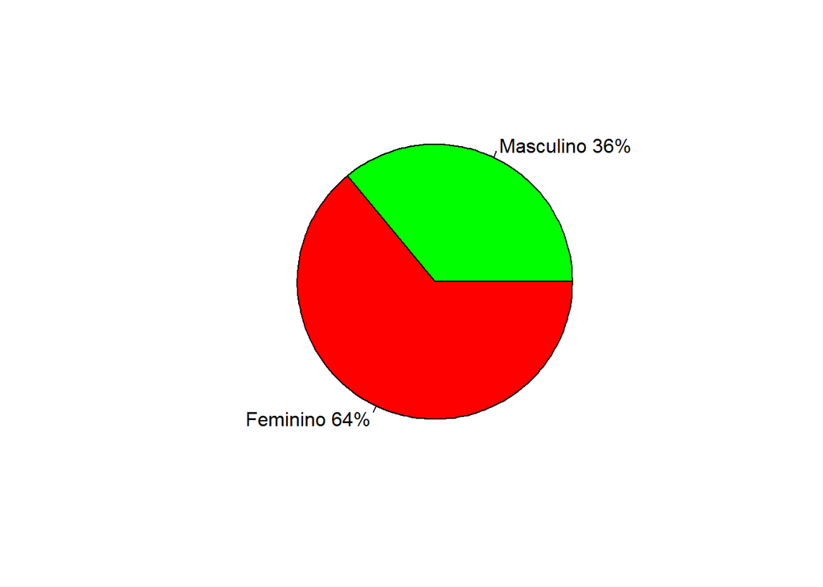

```r
tab_sexo<-table(Sexo)
percent<-prop.table(table(Sexo))*100
rotulos<-c("Masculino","Feminino")
rotulos<-paste(rotulos,percent)  ## a função paste serve para concatenar objetos
rotulos<-paste(rotulos,"%",sep="")
pie(tab_sexo,labels =rotulos,col=c("green","red"))
```

### Gráfico de barras

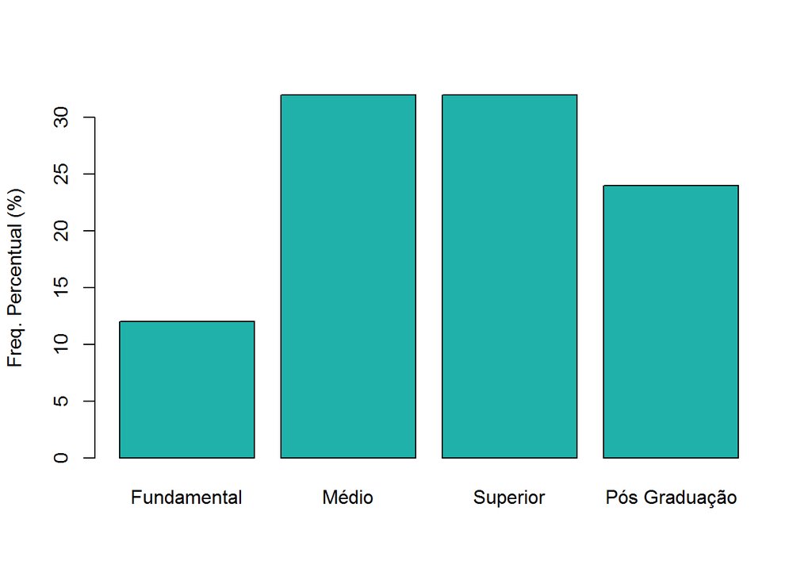

```r
tab_escol<-table(Escola)
percent<-prop.table(table(Escola))*100
barplot(percent,col="lightseagreen",names.arg=c("Fundamental","Médio","Superior","Pós Graduação"),ylab="Freq. Percentual (%)")
```

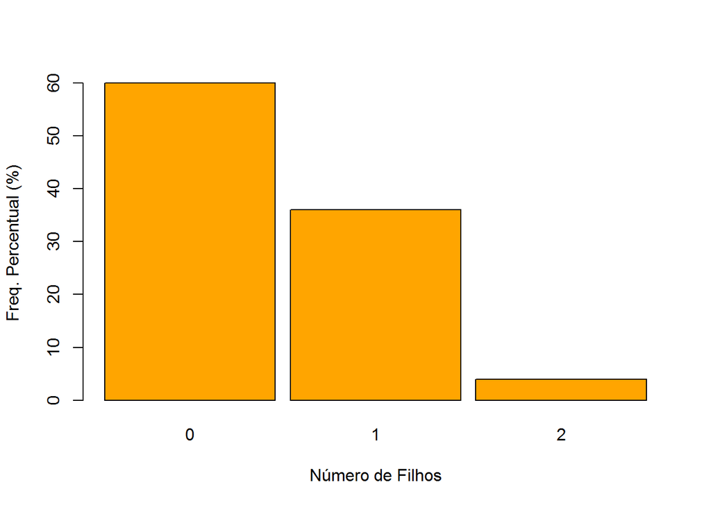

```r
tab_filhos<-table(Núm..Filhos)
percent<-prop.table(table(Núm..Filhos))*100
barplot(percent,col="orange",Núm..Filhos,ylab="Freq. Percentual (%)",xlab="Número de Filhos")
```

### Histograma

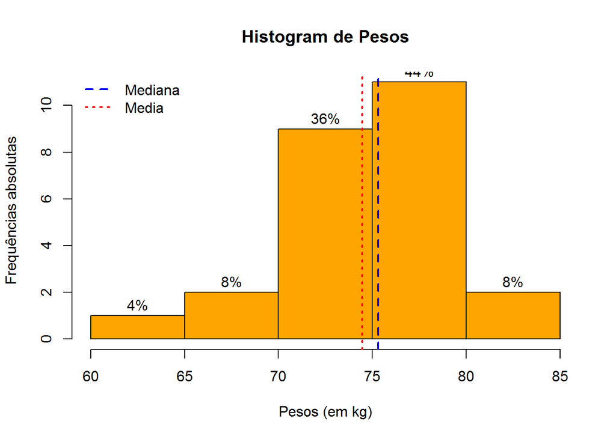

```r
hist_peso<-hist(peso,breaks=5,plot=F)
hist_peso<-hist(peso,breaks=5,plot=F)
percent<-(hist_peso$density*(hist_peso$breaks[2]-hist_peso$breaks[1]))*100
percent<-paste(percent,"%",sep="")
hist_peso<-hist(peso,breaks=5,freq=T,labels=percent,xlab="Pesos (em kg)",ylab="Frequências absolutas",main="Histogram de Pesos",col="orange")
# acrescentando quadro com legenda
abline(v=c(median(peso),mean(peso)),lty=c(2,3),lwd=c(2,2),col=c("blue","red"))
legend("topleft", #posição da legenda
       c("Mediana","Media"), #nomes da legenda
       col=c("blue","red"), #cores
       lty=c(2,3), #estilo da linha
       lwd=c(2,2),bty="n") #grossura das linhas
```

### OUTRA OPÇÃO PARA FAZER O HISTOGRAMA

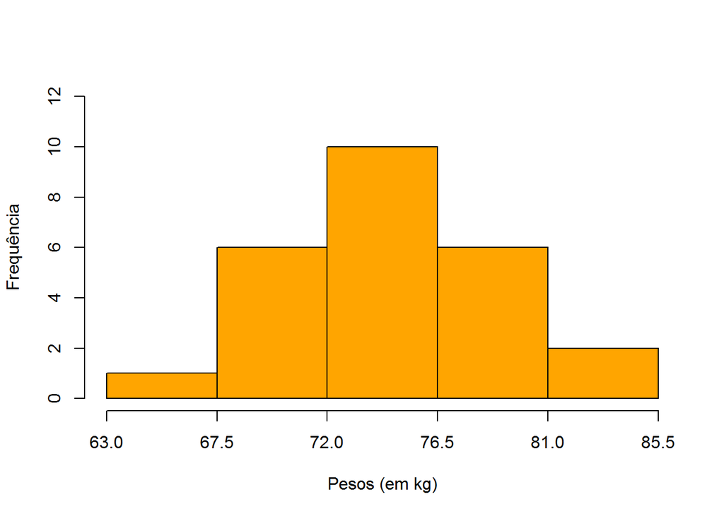

```r
#install.packages('fdth')
library(fdth)
tab<-fdt(peso, start=63,h=4.5,end=85.5)
plot(tab,xlab="Pesos (em kg)",ylab="Frequência",col="orange")
```

### Polígono de frequência

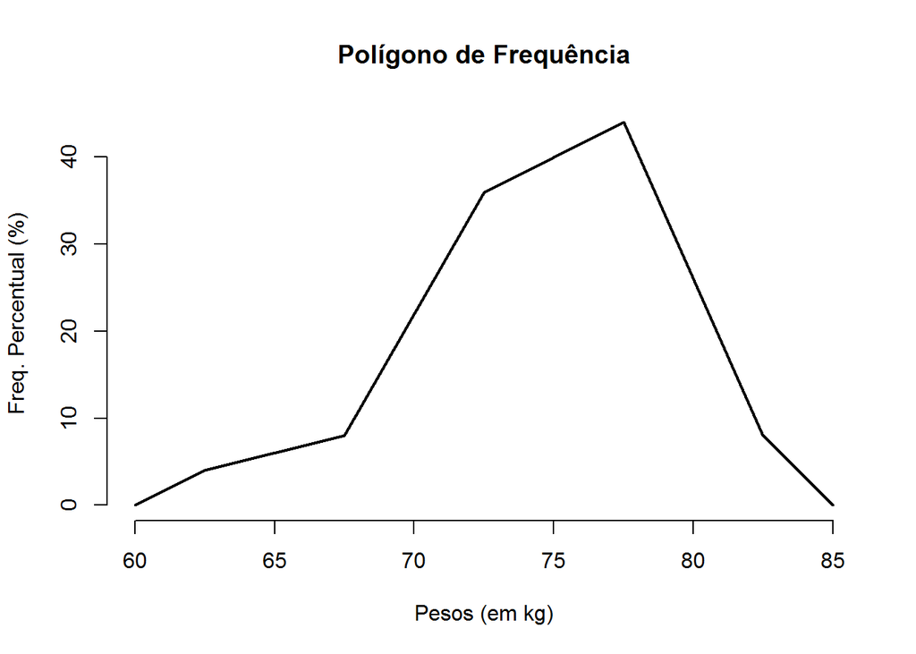

```r
x<-c(min(hist_peso$breaks),hist_peso$mids,max(hist_peso$breaks))
y<-c(0,hist_peso$density*(hist_peso$breaks[2]-hist_peso$breaks[1])*100,0)
plot(x,y,type="l",bty='n',lwd=2,xlab="Pesos (em kg)",ylab='Freq. Percentual (%)',main="Polígono de Frequência")
```

### Gráfico de Ogiva

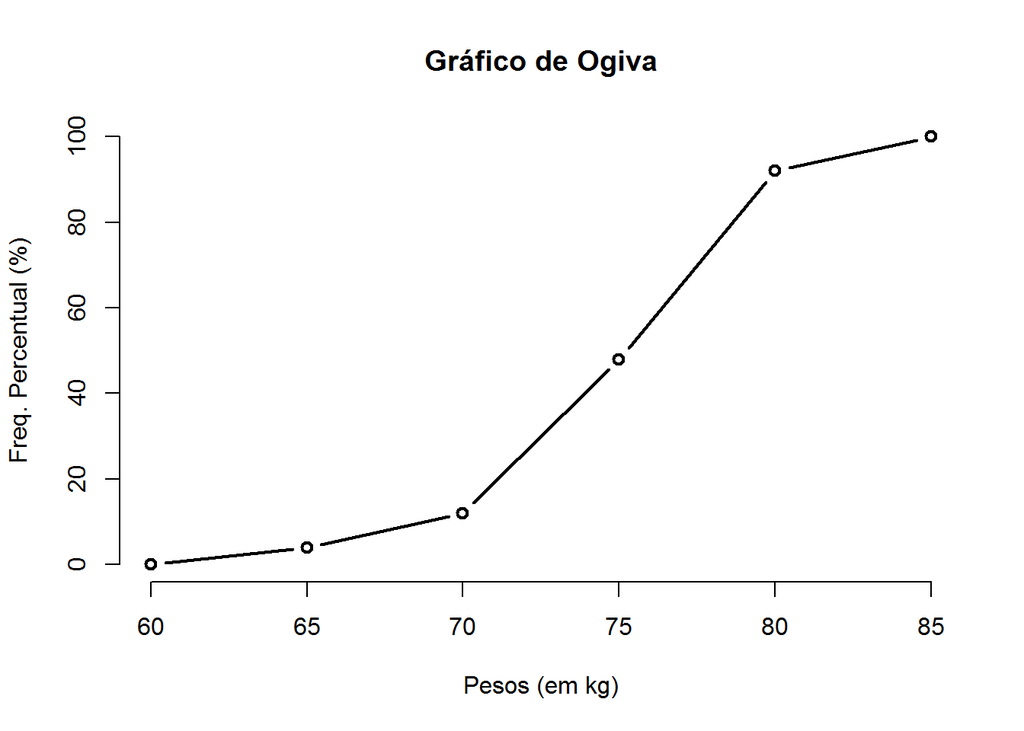

```r
x<-c(hist_peso$breaks)
y<-c(0,cumsum(hist_peso$density*(hist_peso$breaks[2]-hist_peso$breaks[1])*100))
plot(x,y,type="b",bty='n',lwd=2,xlab="Pesos (em kg)",ylab='Freq. Percentual (%)',main="Gráfico de Ogiva")
```

### Gráfico de dispersão

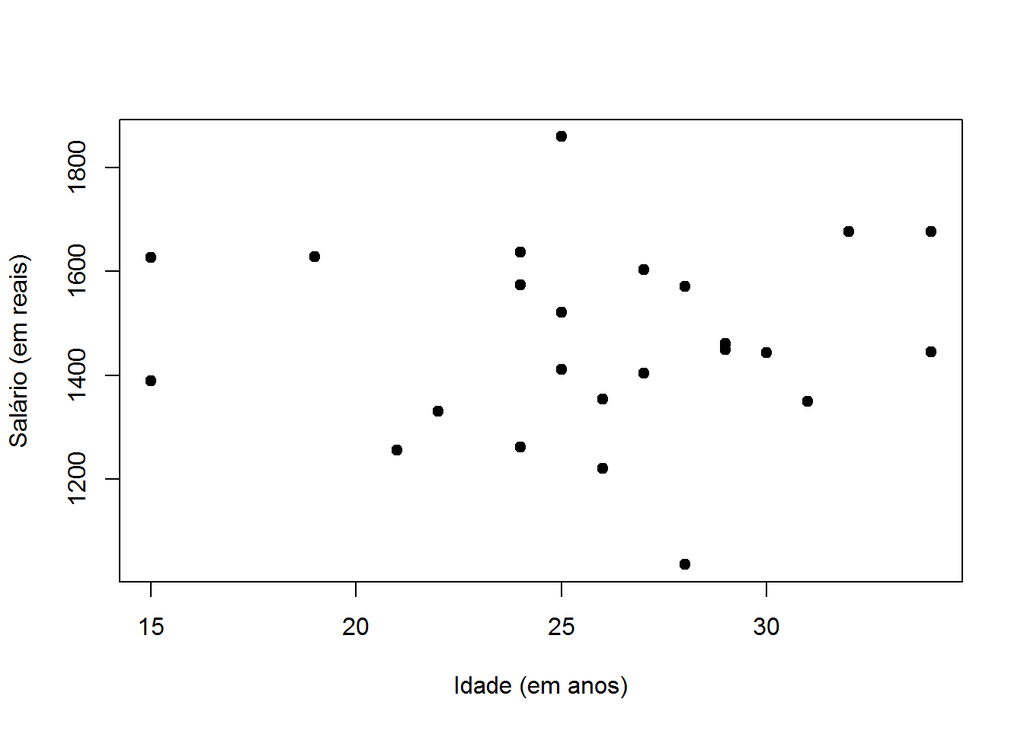

```r
plot(Idade,Salário,pch=20,cex=1.5,xlab="Idade (em anos)",ylab="Salário (em reais)")
```

```r
cor(Idade,Salário) ## Calcula a correlação linear entre duas variáveis quantitativas
```

```
## [1] 0.02047677
```

### Gráfico de Séries temporais

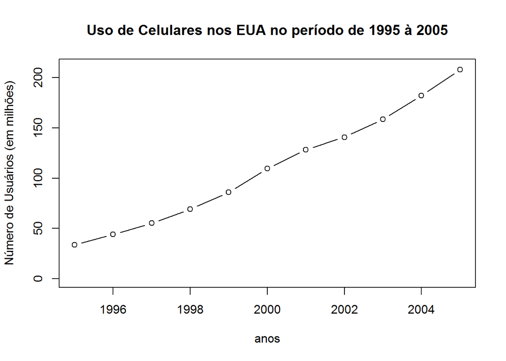

```r
anos<-c(1995:2005)
usuarios<-c(33.8,44,55.3,69.2,86,109.5,128.4,140.8,158.7,182.1,207.9)
#Gráfico de linhas
plot(anos,usuarios,type='b',ylim=c(0,210),xlab="anos",ylab="Número de Usuários (em milhões)", main="Uso de Celulares nos EUA no período de 1995 à 2005")
```

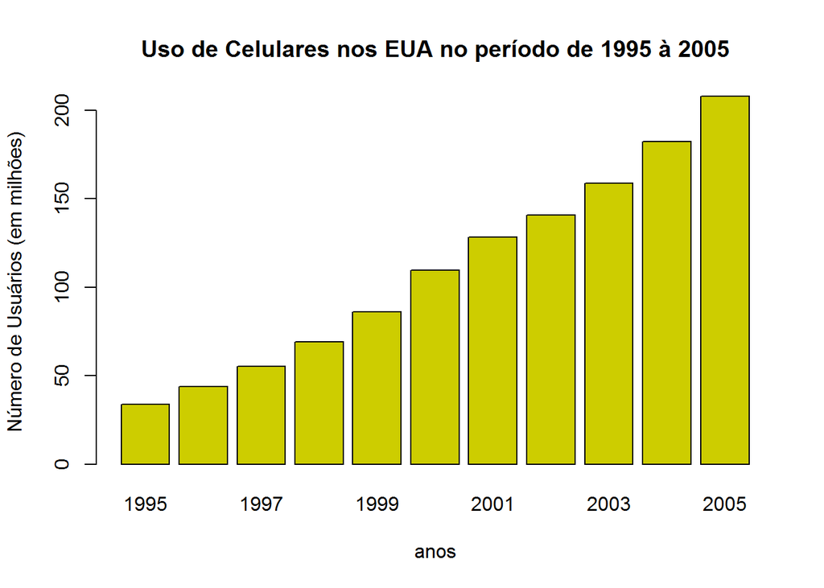

```r
#Gráfico de Barras
barplot(height=usuarios,width=anos,names.arg=anos,xlab="anos",ylab="Número de Usuários (em milhões)",col="yellow3",main="Uso de Celulares nos EUA no período de 1995 à 2005")
```

### Gráfico de Pareto

```r
require(qualityTools)
```

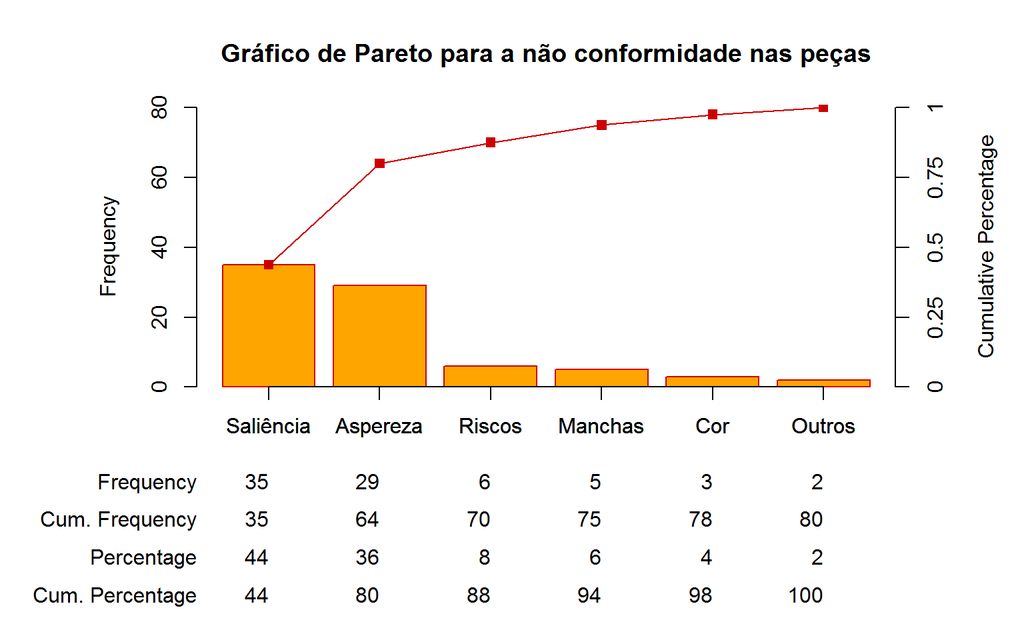

```
##
## Frequency          35    29     6     5     3      2
## Cum. Frequency     35    64    70    75    78     80
## Percentage      43.8% 36.2%  7.5%  6.2%  3.8%   2.5%
## Cum. Percentage 43.8% 80.0% 87.5% 93.8% 97.5% 100.0%
```

```
##
## Frequency       35.00 29.00  6.0  5.00  3.00   2.0
## Cum. Frequency  35.00 64.00 70.0 75.00 78.00  80.0
## Percentage      43.75 36.25  7.5  6.25  3.75   2.5
## Cum. Percentage 43.75 80.00 87.5 93.75 97.50 100.0
```

```r
#install.packages('qualityTools')
paretoPlot
nconf<-c(rep("Saliência",35),rep("Aspereza",29),rep("Riscos",6),rep("Manchas",5),rep("Cor",3),rep("Outros",2))
paretoChart(nconf,col="orange",main="Gráfico de Pareto para a não conformidade nas peças")
```

## Resumos numéricos

Quando adicionarmos um resumo numérico, devemos sempre optar por uma ou mais medidas de tendência central (média, mediana e moda) e uma ou mais medidas de dispersão (amplitude, distância interquartílica, variância amostral, desvio padrão amostral e coeficiente de variação), pois apresentar uma medida de centro sozinha pode ser enganosa e omitir várias informações do comportamento dos dados em relação ao centro.

### Média amostral

```r
dados<-c(5.00,7.00,7.00,10.00,12.00,15.00,19.00,18.00,10.00,10.00)
mean(dados)
```

```
## [1] 11.3
```

### Mediana

```r
dados2<-c(23,4,6,12,4,4,7,19,15)
median(dados)
```

```
## [1] 10
```

### Moda

```r
dados3<-c(1,5,3,1,2,1,5,1,2,2,5,1,4,4)
moda<-function(d)
{
  if ((is.numeric(d)==TRUE) && (is.list(d)==FALSE))
  {
    dd<-table(d)
    valores<-which(dd==max(dd))
    vmodal<-0
    for(i in 1: (length(valores)))
      if (i==1)
        vmodal<-as.numeric(names(valores[i]))
    else
      vmodal<-c(vmodal,as.numeric(names(valores[i])))
    if(length(vmodal)==length(dd))
      print("conjunto sem valor modal")
    else
      return(vmodal)
  }
  elseprint("o parâmetro deve ser um vetor ou matriz")
}

moda(dados3)  # Unimodal
```

```
## [1] 1
```

```r
dados4<-c(7,12,5,12,5,8,9,5,6,12)
moda(dados4)  # Bimodal
```

```
## [1]  5 12
```

### Amplitude

```r
empresaA<-c(4100,3800,3900,4500,4700,4100,4400,4100,3700,4200)
amp_a<-max(empresaA)-min(empresaA)
amp_a
```

```
## [1] 1000
```

```r
empresaB<-c(4000,2300,4100,5000,4900,3200,4100,2900,5200,5800)
amp_b<-max(empresaB)-min(empresaB)
amp_b
```

```
## [1] 3500
```

## Variância amostral, Desvio padrão amostral e coeficiente de variação

```r
gelad<-c(750.00,800.00,790.00,810.00,820.00,760.00,780.00)
# variância amostral
var(gelad)
```

```
## [1] 657.1429
```

```r
# Desvio padrão amostral
sd(gelad)
```

```
## [1] 25.6348
```

```r
# coeficiente de variação
cv_gel<-(sd(gelad)/mean(gelad))*100
cv_gel
```

```
## [1] 3.256689
```

```r
liquid<-c(50,45,55,43,52,45,54)
# variância amostral
var(liquid)
```

```
## [1] 23.14286
```

```r
# Desvio padrão amostral
sd(liquid)
```

```
## [1] 4.810702
```

```r
cv_liquid<-(sd(liquid)/mean(liquid))*100
cv_liquid
```

```
## [1] 9.78922
```

## Medidas descritivas da variável quantitativa em cada categoria da qualitativa

```r
dados<-read.csv2("G:\\AULAS_FATEC_2ºSEM_2019\\ADS_NOITE\\ESTATÍSTICA\\ESTATÍSTICA COM O USO DO R\\dados\\quest_sastif.csv",h=T)
attach(dados)
# Média de Salário
mean(Salário)
```

```
## [1] 1465.74
```

```r
# Média de Salário de homens
mean(Salário[Sexo==0])
```

```
## [1] 1454.168
```

```r
# Média de Salário de mulheres
mean(Salário[Sexo==1])
```

```
## [1] 1472.25
```

### Resumo numérico fornecendo várias estatísticas

```r
summary(Salário)
```

```
##    Min. 1st Qu.  Median    Mean 3rd Qu.    Max.
##    1035    1354    1449    1466    1603    1859
```

```r
summary(dados[c("Salário","Idade","peso","altura","Núm..Filhos","TV")])
```

```
##     Salário         Idade            peso           altura
##  Min.   :1035   Min.   :15.00   Min.   :63.00   Min.   :1.610
##  1st Qu.:1354   1st Qu.:24.00   1st Qu.:71.50   1st Qu.:1.760
##  Median :1449   Median :26.00   Median :75.30   Median :1.800
##  Mean   :1466   Mean   :25.96   Mean   :74.46   Mean   :1.789
##  3rd Qu.:1603   3rd Qu.:29.00   3rd Qu.:76.70   3rd Qu.:1.830
##  Max.   :1859   Max.   :34.00   Max.   :83.50   Max.   :1.900
##   Núm..Filhos         TV
##  Min.   :0.00   Min.   :1.500
##  1st Qu.:0.00   1st Qu.:2.400
##  Median :0.00   Median :3.300
##  Mean   :0.44   Mean   :3.168
##  3rd Qu.:1.00   3rd Qu.:3.600
##  Max.   :2.00   Max.   :4.700
```

### Uma alternativa de resumo numéricos

```r
# install.package("psych")
require(psych)
describe(Salário,skew=F)
```

```
##    vars  n    mean     sd     min     max  range    se
## X1    1 25 1465.74 177.78 1035.26 1859.41 824.15 35.56
```

```r
describe(dados[c("Salário","Idade","peso","altura","Núm..Filhos","TV")],skew=F)
```

```
##             vars  n    mean     sd     min     max  range    se
## Salário        1 25 1465.74 177.78 1035.26 1859.41 824.15 35.56
## Idade          2 25   25.96   4.95   15.00   34.00  19.00  0.99
## peso           3 25   74.46   4.42   63.00   83.50  20.50  0.88
## altura         4 25    1.79   0.08    1.61    1.90   0.29  0.02
## Núm..Filhos    5 25    0.44   0.58    0.00    2.00   2.00  0.12
## TV             6 25    3.17   0.85    1.50    4.70   3.20  0.17
```

```r
# Resumo numérico por sexo
describeBy(dados[c("Salário","Idade","peso","altura","Núm..Filhos","TV")],skew=F,group=Sexo)
```

```
##
##  Descriptive statistics by group
## group: 0
##             vars n    mean     sd     min     max  range    se
## Salário        1 9 1454.17 217.69 1220.36 1859.41 639.05 72.56
## Idade          2 9   26.89   3.92   21.00   34.00  13.00  1.31
## peso           3 9   74.72   4.16   70.80   83.50  12.70  1.39
## altura         4 9    1.78   0.08    1.61    1.89   0.28  0.03
## Núm..Filhos    5 9    0.22   0.44    0.00    1.00   1.00  0.15
## TV             6 9    3.23   1.04    1.50    4.70   3.20  0.35
## --------------------------------------------------------
## group: 1
##             vars  n    mean     sd     min     max  range    se
## Salário        1 16 1472.25 158.65 1035.26 1676.05 640.79 39.66
## Idade          2 16   25.44   5.50   15.00   34.00  19.00  1.38
## peso           3 16   74.31   4.68   63.00   81.50  18.50  1.17
## altura         4 16    1.80   0.08    1.67    1.90   0.23  0.02
## Núm..Filhos    5 16    0.56   0.63    0.00    2.00   2.00  0.16
## TV             6 16    3.13   0.76    1.90    4.50   2.60  0.19
```

## Medidas Separatrizes: Quartis, Decis e percentins

```r
### Quartis ###
dados1<-c(15,5,3,8,10,2,7,11,12,67)
quantile(dados1,type=2)
```

```
##   0%  25%  50%  75% 100%
##    2    5    9   12   67
```

```r
### Decis ####
dados2<-c(0.5,0.7,0.7,0.9,1.0,1.1,1.1,1.2,1.3,1.3,1.5,1.8,2.1,2.2,2.5,2.5)
p<-seq(0.1,1,0.1)
quantile(dados2,p,type=2)
```

```
##  10%  20%  30%  40%  50%  60%  70%  80%  90% 100%
## 0.70 0.90 1.00 1.10 1.25 1.30 1.80 2.10 2.50 2.50
```

```r
### Percentins ###
p<-seq(0.01,1,0.01)
quantile(dados2,p,type=2)
```

```
##   1%   2%   3%   4%   5%   6%   7%   8%   9%  10%  11%  12%  13%  14%  15%
## 0.50 0.50 0.50 0.50 0.50 0.50 0.70 0.70 0.70 0.70 0.70 0.70 0.70 0.70 0.70
##  16%  17%  18%  19%  20%  21%  22%  23%  24%  25%  26%  27%  28%  29%  30%
## 0.70 0.70 0.70 0.90 0.90 0.90 0.90 0.90 0.90 0.95 1.00 1.00 1.00 1.00 1.00
##  31%  32%  33%  34%  35%  36%  37%  38%  39%  40%  41%  42%  43%  44%  45%
## 1.00 1.10 1.10 1.10 1.10 1.10 1.10 1.10 1.10 1.10 1.10 1.10 1.10 1.20 1.20
##  46%  47%  48%  49%  50%  51%  52%  53%  54%  55%  56%  57%  58%  59%  60%
## 1.20 1.20 1.20 1.20 1.25 1.30 1.30 1.30 1.30 1.30 1.30 1.30 1.30 1.30 1.30
##  61%  62%  63%  64%  65%  66%  67%  68%  69%  70%  71%  72%  73%  74%  75%
## 1.30 1.30 1.50 1.50 1.50 1.50 1.50 1.50 1.80 1.80 1.80 1.80 1.80 1.80 1.95
##  76%  77%  78%  79%  80%  81%  82%  83%  84%  85%  86%  87%  88%  89%  90%
## 2.10 2.10 2.10 2.10 2.10 2.10 2.20 2.20 2.20 2.20 2.20 2.20 2.50 2.50 2.50
##  91%  92%  93%  94%  95%  96%  97%  98%  99% 100%
## 2.50 2.50 2.50 2.50 2.50 2.50 2.50 2.50 2.50 2.50
```

### Gráfico boxplot

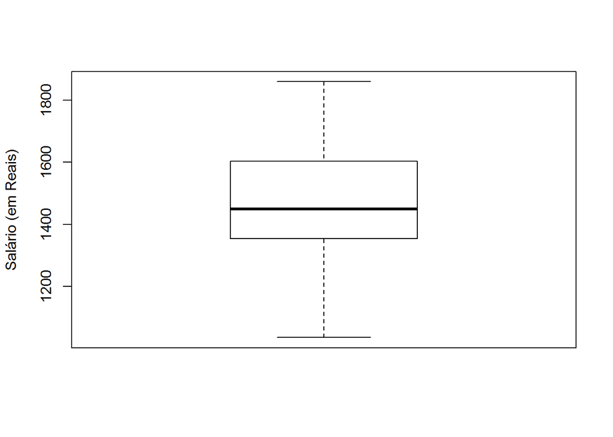

```r
boxplot(Salário,ylab="Salário (em Reais)")
```

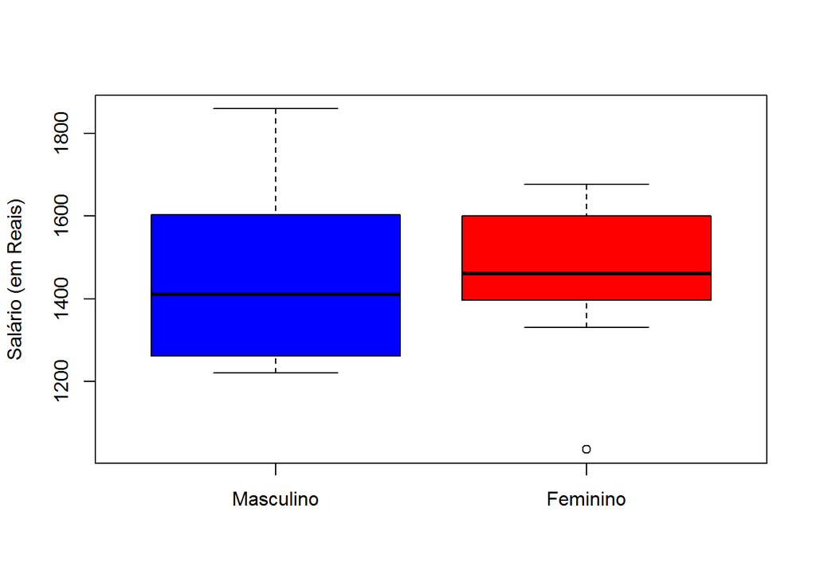

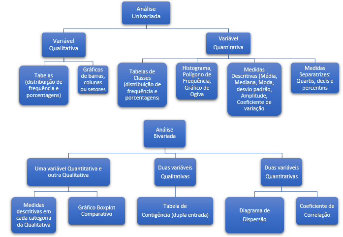

Esquema geral para análise exploratória de dados.

```r
# Boxplot por grupo
boxplot(Salário~Sexo,names=c("Masculino","Feminino"),col=c(4,2),ylab="Salário (em Reais)")
```

## Algumas funções de Análise Combinatória e de Probabilidade

### Arranjo Simples

Arranjos simples de n elementos tomados p a p ($p\leq n$) são os agrupamentos **ordenados** diferentes que se podem formar com p dos n elementos. Indica-se por $A_{n, p}$, o total desses agrupamentos, que calculamos assim:

$$A_{n, p}=\frac{n!}{(n-p)!}$$

```r
arranjo<-function(n,p)
{
  arranjo<-factorial(n)/factorial(n-p)
  return(arranjo)
  }
arranjo(5,2)
```

```
## [1] 20
```

**A ordem no arranjo é importante !!! Note que a permutação é um caso particular de arranjo.**

### Combinação Simples

Combinações simples de n elementos tomados p a p ($p\leq n$) são os agrupamentos **não ordenados** diferentes que se podem formar com p dos n elementos. Se em determinado grupo a **ordem não for importante**, teremos uma combinação.

$$C_{n,\,p}=\left(\begin{array}{cc}
n \\
p
\end{array}\right)
=\frac{n!}{(n-p)!\cdot p!}$$
#### Mostrando todos os elementos de uma combinação

```r
tipos<-c("Bombom 1","Bombom 2","Bombom 3","Bombom 4","Bombom 5")
combn(tipos,3)
```

```
##      [,1]       [,2]       [,3]       [,4]       [,5]       [,6]
## [1,] "Bombom 1" "Bombom 1" "Bombom 1" "Bombom 1" "Bombom 1" "Bombom 1"
## [2,] "Bombom 2" "Bombom 2" "Bombom 2" "Bombom 3" "Bombom 3" "Bombom 4"
## [3,] "Bombom 3" "Bombom 4" "Bombom 5" "Bombom 4" "Bombom 5" "Bombom 5"
##      [,7]       [,8]       [,9]       [,10]
## [1,] "Bombom 2" "Bombom 2" "Bombom 2" "Bombom 3"
## [2,] "Bombom 3" "Bombom 3" "Bombom 4" "Bombom 4"
## [3,] "Bombom 4" "Bombom 5" "Bombom 5" "Bombom 5"
```

Calculando as combinações simples:

```r
comb<-function(n,p)
{
  combinacao<-factorial(n)/(factorial(n-p)*factorial(p))
  return(combinacao)
}
comb(5,3)
```

```
## [1] 10
```

Para calcular combinações no R, existe a função *choose()*:

```r
choose(5,3)
```

```
## [1] 10
```

### Distribuições de Probabilidade

O R possui uma série de distribuições de probabilidade, usando o comando *help(“Distributions”)*, você visualizará as distribuições do pacote **stats**. Para cada distribuição temos quatro funções comuns.

- d: calcula a densidade de probabilidade f(x) no ponto, exemplo: **d**norm
- p: calcula a função de probabilidade ou função de distribuição acumulada, exemplo: **p**norm
- q: calcula o quantil correspondente a uma dada probabildade, exemplo: **q**norm
- r: retira uma amostra de números aleatórios da distribuição, exemplo: **r**norm
1. Binomial

Considere que a variável aleatória $X \sim Binomial(10;0,35)$.

```r
k<-0:10
round(dbinom(k,size=10,prob=0.35),4)
```

```
##  [1] 0.0135 0.0725 0.1757 0.2522 0.2377 0.1536 0.0689 0.0212 0.0043 0.0005
## [11] 0.0000
```

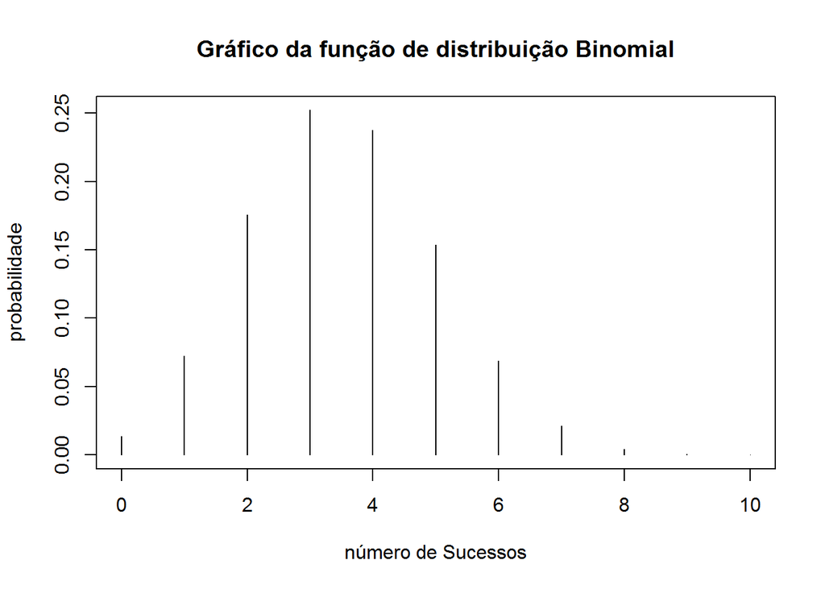

```r
# k: o vetor do número de sucessos
#size: O números de ensaios independentes
#prop: Probabilidade de sucesso em cada ensaio
plot(k,dbinom(k,10,0.35),type="h",xlab="número de Sucessos",ylab="probabilidade",main="Gráfico da função de distribuição Binomial")
```

Calcule a $P(X=7)$:

```r
dbinom(7,10,0.35)
```

```
## [1] 0.02120302
```

Função de distribuição acumulada $P(X\leq k)$

```r
pbinom(x,10,0.35)
```

```
## [1] 1 1 1 1 1 1
```

Calcule a $P(X<=7)$:

```r
pbinom(7,10,0.35)
```

```
## [1] 0.9951787
```

Gerar 5 números aleatórios da distribuição Binomial.

```r
rbinom(5,100,0.35)
```

```
## [1] 31 31 39 38 32
```

2. Poisson

Considere que a variável aleatória $X \sim Poisson(3)$.

Função de distribuição Poisson:
$$P(X=k)=\frac{e^{-\lambda}\cdot \lambda^{x}}{x!} ,\, x=0,1,2, \cdots$$
.

```r
x<-0:20
round(dpois(x,lambda=3),4)
```

```
##  [1] 0.0498 0.1494 0.2240 0.2240 0.1680 0.1008 0.0504 0.0216 0.0081 0.0027
## [11] 0.0008 0.0002 0.0001 0.0000 0.0000 0.0000 0.0000 0.0000 0.0000 0.0000
## [21] 0.0000
```

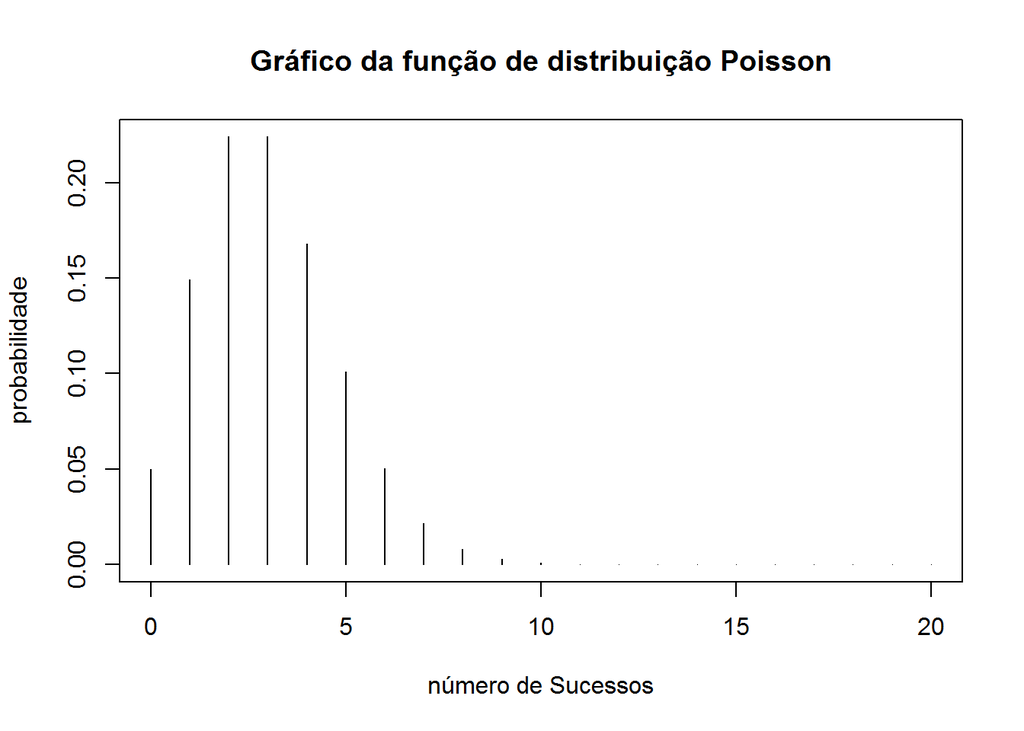

```r
# x: o vetor do número de sucessos por intervalo
#lambda: taxa de sucesso por unidade do intervalo
plot(x,dpois(x,lambda=3),type="h",xlab="número de Sucessos",ylab="probabilidade",main="Gráfico da função de distribuição Poisson")
```

Calcule a $P(X=7)$:

```r
dpois(7,3)
```

```
## [1] 0.02160403
```

Função de distribuição acumulada $P(X\leq k)$

```r
ppois(x,3)
```

```
##  [1] 0.04978707 0.19914827 0.42319008 0.64723189 0.81526324 0.91608206
##  [7] 0.96649146 0.98809550 0.99619701 0.99889751 0.99970766 0.99992861
## [13] 0.99998385 0.99999660 0.99999933 0.99999988 0.99999998 1.00000000
## [19] 1.00000000 1.00000000 1.00000000
```

Calcule a $P(X<=7)$:

```r
ppois(7,3)
```

```
## [1] 0.9880955
```

Gerar 5 números aleatórios da distribuição Poisson.

```r
rpois(5,3)
```

```
## [1] 3 0 3 2 3
```

3. Distribuição Normal

Considere que a variável aleatória $X \sim Normal(0,1)$.

Função de densidade de probabilidade:
$$f(x)=\frac{1}{\sqrt{2 \pi} \sigma}\cdot e^{-\frac{1}{2}\cdot\left(\frac{x-\mu}{\sigma}\right)^2 }, \,\, -\infty<x<+\infty$$
.

```r
x<--4:4
round(dnorm(x,mean=0,sd=1),4)
```

```
## [1] 0.0001 0.0044 0.0540 0.2420 0.3989 0.2420 0.0540 0.0044 0.0001
```

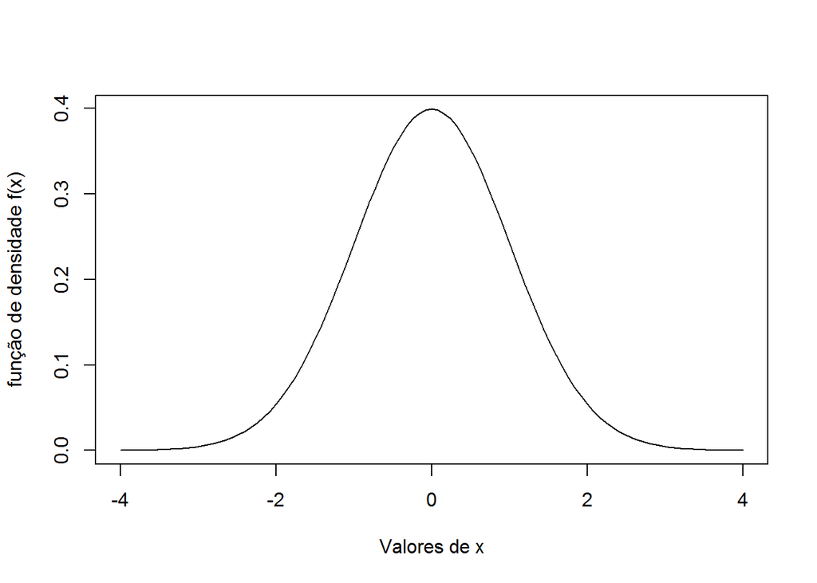

```r
curve(dnorm(x,mean=0,1),from=-4,to=4,xlab="Valores de x",ylab="função de densidade f(x)")
```

Outros exemplos de funções de densidade da distribuição Normal

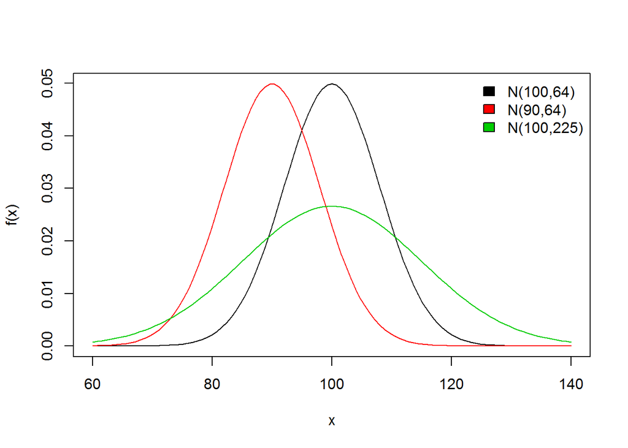

```r
curve(dnorm(x,100,8),60,140,ylab="f(x)")
curve(dnorm(x,90,8),60,140,add=T,col=2)
curve(dnorm(x,100,15),60,140,add=T,col=3)
legend("topright",c("N(100,64)","N(90,64)","N(100,225)"),fill=1:3,bty="n")
```

```r
#Obs. O comando bty="n", faz com que não se crie uma caixa no entorno da legenda
```

Função de distribuição Acumulada $F(x)= P(X \leq x)$

```r
pnorm(-1) ## Área sob a curva
```

```
## [1] 0.1586553
```

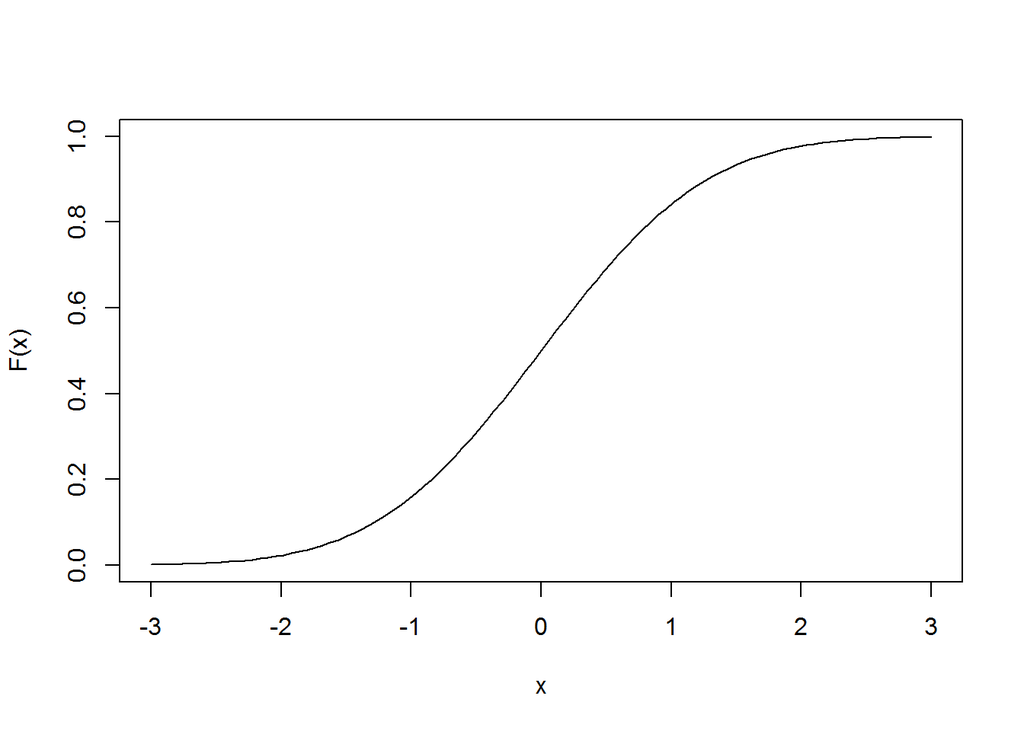

```r
x<--3:3
curve(pnorm(x,0,1),-3,3,ylab="F(x)")
```

Encontre na distribuição normal padrão o valor de c, tal que $P(Z\leq c)=0,975$

```r
qnorm(0.975,mean=0,sd=1)
```

```
## [1] 1.959964
```

Exercício: Dada a distribuição Normal(100,100), encontre:

1. $P(X<95)$

```r
pnorm(95,100,10)
```

```
## [1] 0.3085375
```

2. $P(90<X<110)$

```r
pnorm(110,100,10)-pnorm(90,100,10)
```

```
## [1] 0.6826895
```

3. $P(X>95)$

```r
1-pnorm(95,100,10)
```

```
## [1] 0.6914625
```

```r
# Outra forma
pnorm(95,100,10,lower=FALSE)
```

```
## [1] 0.6914625
```

Gerar 5 números aleatórios da distribuição Normal Padrão.

```r
rnorm(5,mean=0,sd=1)
```

```
## [1] -0.1939469  1.3964315  0.1006632 -0.1144388  0.7022252
```